# W3cubDocs

/ReactNative

# SegmentedControlIOS

Use `SegmentedControlIOS` to render a UISegmentedControl iOS.

#### Programmatically changing selected index

The selected index can be changed on the fly by assigning the selectedIndex prop to a state variable, then changing that variable. Note that the state variable would need to be updated as the user selects a value and changes the index, as shown in the example below.

## Example

```
<SegmentedControlIOS
  values={['One', 'Two']}
  selectedIndex={this.state.selectedIndex}
  onChange={(event) => {
    this.setState({selectedIndex: event.nativeEvent.selectedSegmentIndex});
  }}
/>
```

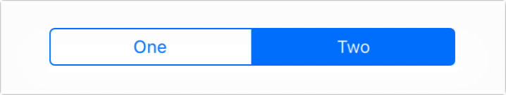

## Props

- View props...
- `enabled`
- `momentary`
- `onChange`
- `onValueChange`
- `selectedIndex`
- `tintColor`
- `values`

# Reference

## Props

### `enabled`

If false the user won't be able to interact with the control. Default value is true.

| Type | Required |
| --- | --- |
| bool | No |

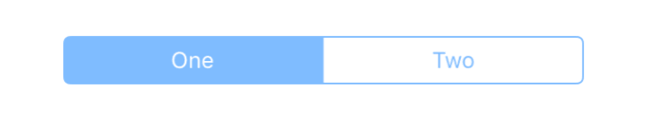

### `momentary`

If true, then selecting a segment won't persist visually. The `onValueChange` callback will still work as expected.

| Type | Required |
| --- | --- |
| bool | No |

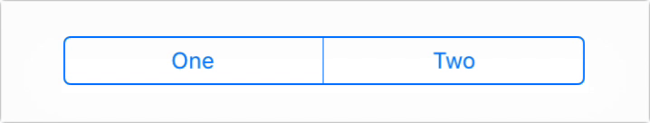

### `onChange`

Callback that is called when the user taps a segment; passes the event as an argument

| Type | Required |
| --- | --- |
| function | No |

### `onValueChange`

Callback that is called when the user taps a segment; passes the segment's value as an argument

| Type | Required |
| --- | --- |
| function | No |

### `selectedIndex`

The index in `props.values` of the segment to be (pre)selected.

| Type | Required |
| --- | --- |
| number | No |

### `tintColor`

Accent color of the control.

| Type | Required |
| --- | --- |
| string | No |

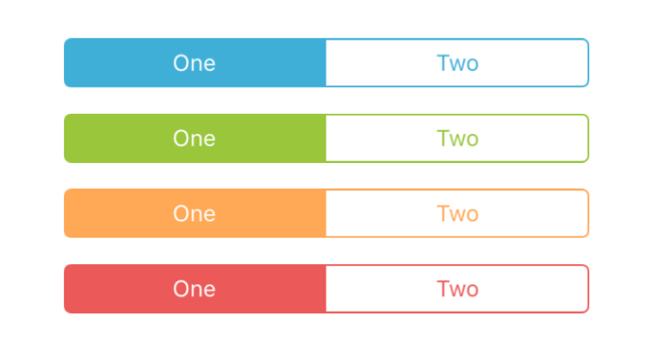

### `values`

The labels for the control's segment buttons, in order.

| Type | Required |
| --- | --- |
| array of string | No |

© 2015–2018 Facebook Inc.  
Licensed under the Creative Commons Attribution 4.0 International Public License.  
https://facebook.github.io/react-native/docs/segmentedcontrolios.html